# Predictive Model for Physical Activity

Patrick Hyland

March 23, 2017

# Executive Summary:

The purpose of this markdown is to describe the analysis conducted on the the activity type given data on movement. Models used after data cleaning were decision tree, random forest, gradient boosted model, and finally a linear discriminant analysis combining the two aforementioned predictors. The final model created brings 99.4% accuracy for predicting class types “A”,“B”,“C”,“D”, and “E”.

## Data clean-up/Model Building

After reading in the data and determing the varying categorical outcomes, I had to load the required packages that would allow for easier data manipulation and machine learning. First, looking at the data I noticed columns that contained any NA values meant that when they had values, it was only for a select number of records. Including these columns would skew the variable importance since it is not representative of most of the other data.

```r
setwd("C:/Users/phyland/Desktop/RWorkingDirectory")

data <- read.csv("pml-training.csv")
library(caret)
library(rattle)
library(ggplot2)
library(randomForest)
for (i in 1:length(data)){
  if (TRUE %in% is.na(data[,i])){
    names(data)[i] <- 'DROP'
  }
}
```

From that point, I had to drop colums that I had marked. In addition, I dropped records for new time windows to hold the variables constant for predicting class and because there are few records of new windows. Also, since the overarching problem is not time relating, I deleted variables pertaining to dates time, and users.

To further asses which variables to eliminate, I conducted a zero variance analysis and cut out the ones whose variance was near 0.

```r
library(data.table)
data<- as.data.table(data)
data<- data[,-('DROP')]
data<- data[data$new_window == 'no',]
data <- data[,-('user_name')]

library(caret)
n<- nearZeroVar(data,saveMetrics = T)
drop<- n[n$zeroVar==TRUE,]
data2<- data[,-c(rownames(drop)),with=F]
data2<- data2[,-('cvtd_timestamp')]
data2<- data2[,5:ncol(data2)]
```

To speed up run time, I set the cross validataion of data to be 60% training and 40% test, versus a 80/20 split which would slow down the analysis when building my model. The training and test were set at random, with the seed set at 567 for reproducibility.

```r
set.seed(567)
inTrain <- createDataPartition(y=data2$classe,p=.6,list = FALSE)
training <- data2[inTrain,]
testing<- data2[-inTrain,]
```

```r
dtfit <- train(classe~., data=training, method='rpart')
```

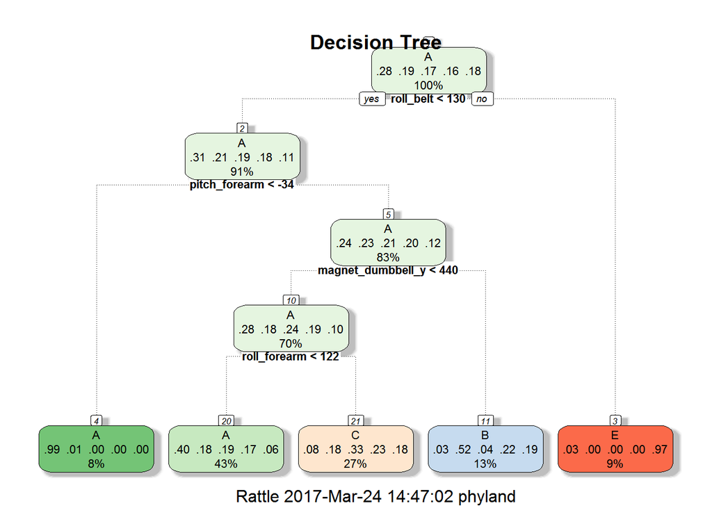

```r
fancyRpartPlot(dtfit$finalModel,main='Decision Tree',cex=.7)
```

```r
vi<-varImp(dtfit)
vi
```

```
## rpart variable importance
##
##   only 20 most important variables shown (out of 52)
##
##                   Overall
## pitch_forearm      100.00
## roll_belt           70.55
## roll_forearm        69.46
## magnet_dumbbell_y   49.08
## accel_belt_z        43.58
## magnet_belt_y       41.42
## yaw_belt            39.78
## magnet_dumbbell_z   37.43
## total_accel_belt    35.71
## magnet_arm_x        27.33
## accel_arm_x         27.05
## roll_dumbbell       18.56
## roll_arm            15.70
## accel_dumbbell_y    15.22
## gyros_belt_x         0.00
## gyros_arm_x          0.00
## magnet_arm_z         0.00
## accel_belt_x         0.00
## magnet_forearm_z     0.00
## accel_dumbbell_z     0.00
```

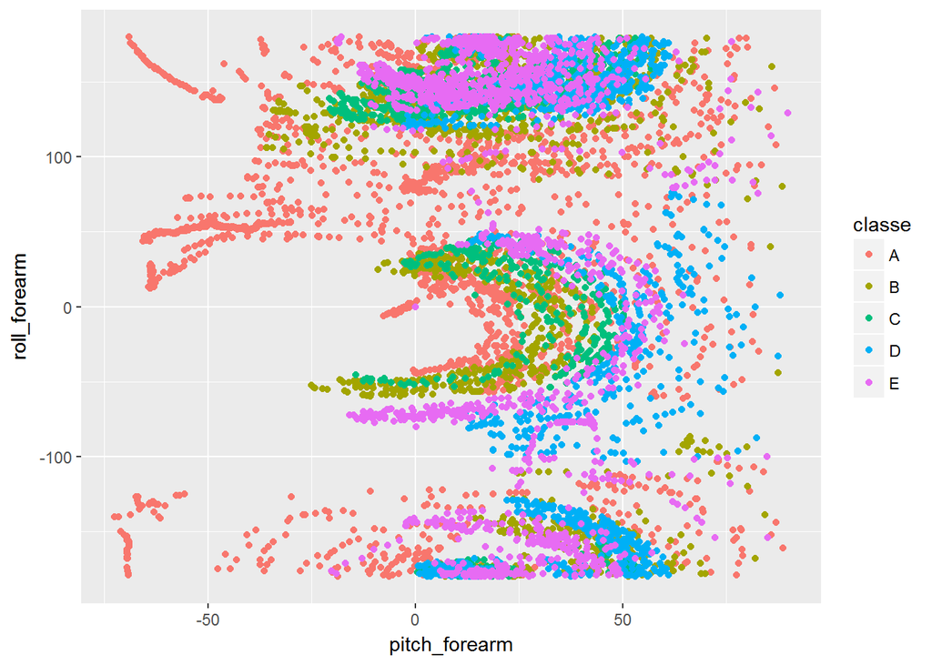

```r
qplot(pitch_forearm,roll_forearm,color=classe,data=training)
```

```r
confusionMatrix(testing$classe,predict(dtfit,testing))
```

```
## Confusion Matrix and Statistics
##
##           Reference
## Prediction    A    B    C    D    E
##          A 1976   29  146    0   37
##          B  617  500  370    0    0
##          C  621   44  675    0    0
##          D  551  234  473    0    0
##          E  188  185  380    0  658
##
## Overall Statistics
##
##                Accuracy : 0.4957
##                  95% CI : (0.4845, 0.5069)
##     No Information Rate : 0.5144
##     P-Value [Acc > NIR] : 0.9995
##
##                   Kappa : 0.3412
##  Mcnemar's Test P-Value : NA
##
## Statistics by Class:
##
##                      Class: A Class: B Class: C Class: D Class: E
## Sensitivity            0.4999  0.50403  0.33023       NA  0.94676
## Specificity            0.9432  0.85251  0.88209   0.8363  0.89226
## Pos Pred Value         0.9031  0.33625  0.50373       NA  0.46634
## Neg Pred Value         0.6403  0.92061  0.78421       NA  0.99410
## Prevalence             0.5144  0.12910  0.26601   0.0000  0.09045
## Detection Rate         0.2572  0.06507  0.08784   0.0000  0.08563
## Detection Prevalence   0.2847  0.19352  0.17439   0.1637  0.18363
## Balanced Accuracy      0.7215  0.67827  0.60616       NA  0.91951
```

```r
gbmfit <- train(classe~.,method='gbm',data=training,verbose=FALSE)
gbmfit$finalModel
```

```
## A gradient boosted model with multinomial loss function.
## 150 iterations were performed.
## There were 52 predictors of which 43 had non-zero influence.
```

```r
confusionMatrix(testing$classe,predict(gbmfit,testing))
```

```
## Confusion Matrix and Statistics
##
##           Reference
## Prediction    A    B    C    D    E
##          A 2155   21    8    1    3
##          B   53 1392   35    3    4
##          C    0   36 1285   16    3
##          D    2    4   39 1209    4
##          E    1   24   17   31 1338
##
## Overall Statistics
##
##                Accuracy : 0.9603
##                  95% CI : (0.9557, 0.9646)
##     No Information Rate : 0.2877
##     P-Value [Acc > NIR] : < 2.2e-16
##
##                   Kappa : 0.9498
##  Mcnemar's Test P-Value : 1.317e-12
##
## Statistics by Class:
##
##                      Class: A Class: B Class: C Class: D Class: E
## Sensitivity            0.9747   0.9425   0.9285   0.9595   0.9896
## Specificity            0.9940   0.9847   0.9913   0.9924   0.9885
## Pos Pred Value         0.9849   0.9361   0.9590   0.9610   0.9483
## Neg Pred Value         0.9898   0.9863   0.9844   0.9921   0.9978
## Prevalence             0.2877   0.1922   0.1801   0.1640   0.1760
## Detection Rate         0.2805   0.1812   0.1672   0.1573   0.1741
## Detection Prevalence   0.2847   0.1935   0.1744   0.1637   0.1836
## Balanced Accuracy      0.9843   0.9636   0.9599   0.9759   0.9891
```

```r
rffit <- randomForest(classe~.,data=training,prox=TRUE)
confusionMatrix(testing$classe,predict(rffit,testing))
```

```
## Confusion Matrix and Statistics
##
##           Reference
## Prediction    A    B    C    D    E
##          A 2188    0    0    0    0
##          B   16 1470    1    0    0
##          C    0    8 1332    0    0
##          D    0    0   12 1245    1
##          E    0    0    0    4 1407
##
## Overall Statistics
##
##                Accuracy : 0.9945
##                  95% CI : (0.9926, 0.9961)
##     No Information Rate : 0.2868
##     P-Value [Acc > NIR] : < 2.2e-16
##
##                   Kappa : 0.9931
##  Mcnemar's Test P-Value : NA
##
## Statistics by Class:
##
##                      Class: A Class: B Class: C Class: D Class: E
## Sensitivity            0.9927   0.9946   0.9903   0.9968   0.9993
## Specificity            1.0000   0.9973   0.9987   0.9980   0.9994
## Pos Pred Value         1.0000   0.9886   0.9940   0.9897   0.9972
## Neg Pred Value         0.9971   0.9987   0.9980   0.9994   0.9998
## Prevalence             0.2868   0.1923   0.1750   0.1625   0.1832
## Detection Rate         0.2847   0.1913   0.1733   0.1620   0.1831
## Detection Prevalence   0.2847   0.1935   0.1744   0.1637   0.1836
## Balanced Accuracy      0.9964   0.9959   0.9945   0.9974   0.9993
```

To see if I could get even better results, I combined these two predictors using linear discriminant analysis. This capitalizes off the strongest accuracies in each model to attempt to bring the greatest amount of accuracy in the final result.

```r
rfpred<- predict(rffit,testing)
gbmpred <- predict(gbmfit,testing)
newdf <- data.frame(rfpred,gbmpred,classe=testing$classe)
combined<- train(classe~.,data=newdf,method='lda')
finpred <- predict(combined,newdf$classe)
confusionMatrix(testing$classe,finpred)
```

```
## Confusion Matrix and Statistics
##
##           Reference
## Prediction    A    B    C    D    E
##          A 2188    0    0    0    0
##          B   16 1470    1    0    0
##          C    0    8 1332    0    0
##          D    0    0   12 1245    1
##          E    0    0    0    4 1407
##
## Overall Statistics
##
##                Accuracy : 0.9945
##                  95% CI : (0.9926, 0.9961)
##     No Information Rate : 0.2868
##     P-Value [Acc > NIR] : < 2.2e-16
##
##                   Kappa : 0.9931
##  Mcnemar's Test P-Value : NA
##
## Statistics by Class:
##
##                      Class: A Class: B Class: C Class: D Class: E
## Sensitivity            0.9927   0.9946   0.9903   0.9968   0.9993
## Specificity            1.0000   0.9973   0.9987   0.9980   0.9994
## Pos Pred Value         1.0000   0.9886   0.9940   0.9897   0.9972
## Neg Pred Value         0.9971   0.9987   0.9980   0.9994   0.9998
## Prevalence             0.2868   0.1923   0.1750   0.1625   0.1832
## Detection Rate         0.2847   0.1913   0.1733   0.1620   0.1831
## Detection Prevalence   0.2847   0.1935   0.1744   0.1637   0.1836
## Balanced Accuracy      0.9964   0.9959   0.9945   0.9974   0.9993
```

The results were identical to that of the random forest. But in case future inputs are extreme, this combined model should be able to handle both.